# Veri Madenciliği Final

Yasemin Hızarcı 121516005

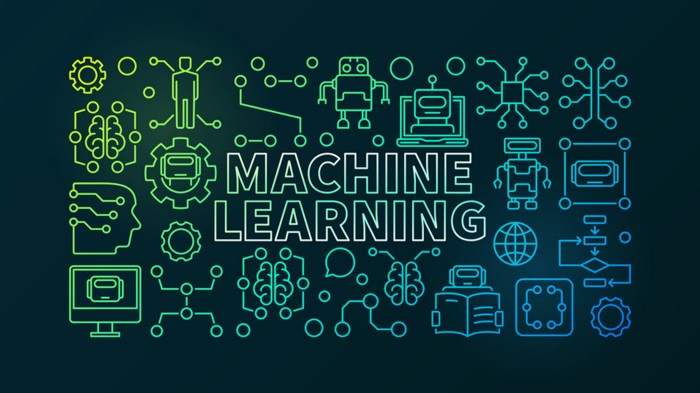

# 1.SORU

## Verinin Tanıtılması:

Fetüs’ün sağlık durumu ile ilgili veri setidir.

**1)** **baseline value:** *Temel Fetal Kalp Hızı (FHR)*

**2)** **accelerations:** *Saniyedeki hızlanma sayısı*

**3)** **fetal_movement:** *Saniyedeki fetal hareket sayısı*

**4)** **uterine_contractions:** *Saniyedeki uterus kasılma sayısı*

**5)** **light_decelerations:** *Saniyedeki LD sayısı*

**6)** **severe_decelerations:** *Saniyedeki SD sayısı*

**7)** **prolongued_decelerations:** *Saniyedeki PD sayısı*

**8)** **abnormal_short_term_variability:** *Anormal kısa vadeli değişkenliğin olduğu zaman yüzdesi*

**9)** **mean_value_of_short_term_variability:** *Kısa vadeli değişkenliğin ortalama değeri*

**10)** **percent_of_time_with_abnormal_long_term_variability:** *Anormal uzun vadeli değişkenliğin olduğu zaman yüzdesi*

**11)** **mean_value_of_long_term_variability:** *Uzun vadeli değişkenliğin ortalama değeri*

**12)** **histogram_width:** *Bir kayıttaki tüm değerler kullanılarak yapılan histogramın genişliği*

**13)** **histogram_min:** *Histogram minimum değeri*

**14)** **histogram_max:** *Histogram maksimum değeri*

**15)** **histogram_number_of_peaks:** *Histogramdaki pik sayısı*

**16)** **histogram_number_of_zeroes:** *Histogramdaki sıfır sayısı*

**17)** **histogram_mode:** *Hist modu*

**18)** **histogram_mean:** *Hist anlamı*

**19)** **histogram_median:** *Hist Medyan*

**20)** **histogram_variance:** *Hist varyansı*

**21)** **histogram_tendency:** *Histogram eğilimi*

**22)** **fetal_health(Fetal sağlık):** *1 - Normal , 0- Patolojik*

**Bağımlı değişken=fetal_health(Fetal sağlık): 1 - Normal, 0 - Patolojik**

```r
library(tidyverse)
library(e1071)
library(caret)
library(tree)
library(InformationValue)
library(ROCR)
library(dplyr)
library(randomForest)
library(gbm)
library(DataExplorer)
library(Amelia)
library(ggplot2)
library(cluster)
library(purrr)
library(factoextra)
library(rpart)
library(rpart.plot)
```

```r
fetal<-read.csv(file='C:/Users/yasem/OneDrive/Masaüstü/fetaldata.csv',
header=TRUE,sep=",")
dim(fetal)
```

```
## [1] 1831   22
```

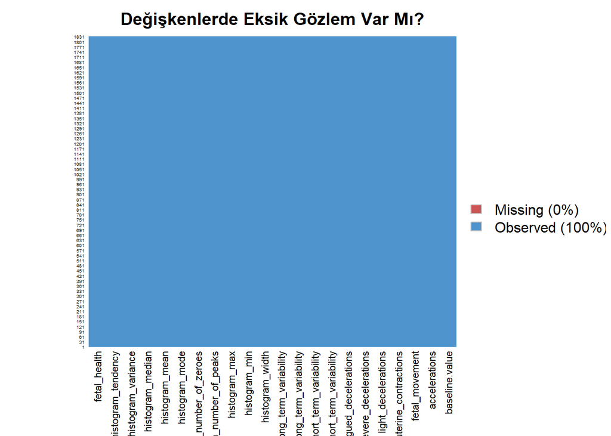

Veride eksik gözlem yoktur.

```r
fetal=fetal%>% mutate(fetal_health= case_when(fetal_health==1~"normal",
fetal_health==0~"hasta"))
```

```r
fetal$histogram_tendency=as.factor(fetal$histogram_tendency)
fetal$fetal_health=as.factor(fetal$fetal_health)
str(fetal)
```

```
## 'data.frame':    1831 obs. of  22 variables:
##  $ baseline.value                                        : int  132 133 134 132 134 134 122 122 122 131 ...
##  $ accelerations                                         : num  0.006 0.003 0.003 0.007 0.001 0.001 0 0 0 0.005 ...
##  $ fetal_movement                                        : num  0 0 0 0 0 0 0 0 0 0.072 ...
##  $ uterine_contractions                                  : num  0.006 0.008 0.008 0.008 0.01 0.013 0 0.002 0.003 0.008 ...
##  $ light_decelerations                                   : num  0.003 0.003 0.003 0 0.009 0.008 0 0 0 0.003 ...
##  $ severe_decelerations                                  : num  0 0 0 0 0 0 0 0 0 0 ...
##  $ prolongued_decelerations                              : num  0 0 0 0 0.002 0.003 0 0 0 0 ...
##  $ abnormal_short_term_variability                       : int  17 16 16 16 26 29 83 84 86 28 ...
##  $ mean_value_of_short_term_variability                  : num  2.1 2.1 2.4 2.4 5.9 6.3 0.5 0.5 0.3 1.4 ...
##  $ percentage_of_time_with_abnormal_long_term_variability: int  0 0 0 0 0 0 6 5 6 0 ...
##  $ mean_value_of_long_term_variability                   : num  10.4 13.4 23 19.9 0 0 15.6 13.6 10.6 12.9 ...
##  $ histogram_width                                       : int  130 130 117 117 150 150 68 68 68 66 ...
##  $ histogram_min                                         : int  68 68 53 53 50 50 62 62 62 88 ...
##  $ histogram_max                                         : int  198 198 170 170 200 200 130 130 130 154 ...
##  $ histogram_number_of_peaks                             : int  6 5 11 9 5 6 0 0 1 5 ...
##  $ histogram_number_of_zeroes                            : int  1 1 0 0 3 3 0 0 0 0 ...
##  $ histogram_mode                                        : int  141 141 137 137 76 71 122 122 122 135 ...
##  $ histogram_mean                                        : int  136 135 134 136 107 107 122 122 122 134 ...
##  $ histogram_median                                      : int  140 138 137 138 107 106 123 123 123 137 ...
##  $ histogram_variance                                    : int  12 13 13 11 170 215 3 3 1 7 ...
##  $ histogram_tendency                                    : Factor w/ 3 levels "-1","0","1": 2 2 3 3 2 2 3 3 3 3 ...
##  $ fetal_health                                          : Factor w/ 2 levels "hasta","normal": 2 2 2 2 1 1 1 1 1 2 ...
```

```r
table(fetal$fetal_health)
```

```
##
##  hasta normal
##    176   1655
```

veride bağımlı değişken için düzensizlik vardır.Bu nedenle veriyi yeniden oluşturup daha sonra test ve train olarak ayırmak istiyorum.

```r
attach(fetal)
health_normal <- fetal[which(fetal$fetal_health == "normal"), ]
health_hasta <- fetal[which(fetal$fetal_health == "hasta"), ]
set.seed(300)
normal<- sample(1:nrow(health_normal), 150)
hasta <- sample(1:nrow(health_hasta), 150)
normal <- health_normal[normal, ]
hasta<- health_hasta[hasta, ]
yeniveri <- rbind(normal, hasta)
table(yeniveri$fetal_health)
```

```
##
##  hasta normal
##    150    150
```

## Test ve Train

Şimdi bu veri üzerinden test ve train setimizi oluşturalım ve klasik sınıflandırma karar ağacı uygulaması yapalım.

```r
set.seed(300)
train=sample(1:nrow(yeniveri), 225) #%75 train
fetal.test=yeniveri[-train,] #%25 test
health.test=yeniveri$fetal_health[-train]  #yanıt değişkeni test
```

##### Train setinde bağımlı değişken

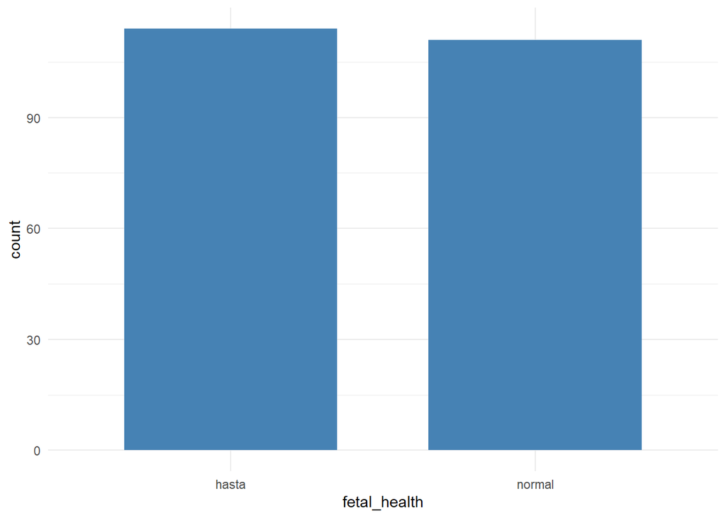

##### Test setinde bağımlı değişken

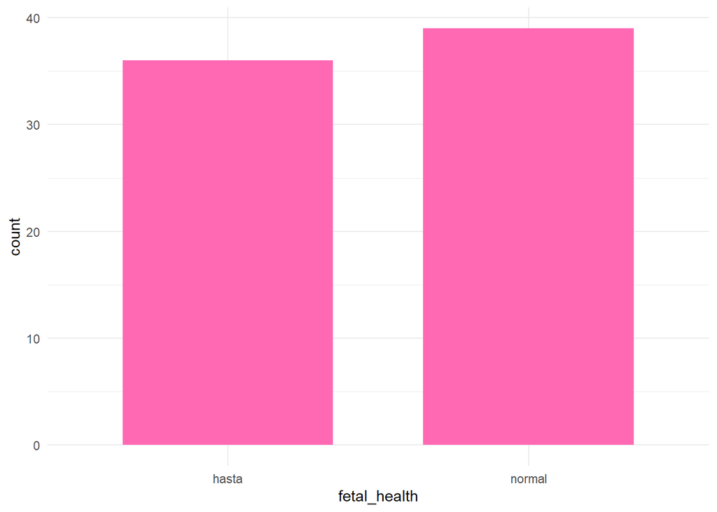

## 1)Klasik Karar Ağacı

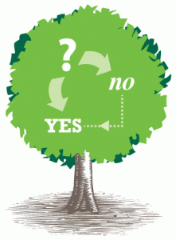

```r
tree.fetal=tree(fetal_health~.,yeniveri,subset=train)
summary(tree.fetal)
```

```
##
## Classification tree:
## tree(formula = fetal_health ~ ., data = yeniveri, subset = train)
## Variables actually used in tree construction:
## [1] "abnormal_short_term_variability"
## [2] "histogram_mean"
## [3] "prolongued_decelerations"
## [4] "baseline.value"
## [5] "histogram_median"
## [6] "mean_value_of_short_term_variability"
## [7] "uterine_contractions"
## Number of terminal nodes:  9
## Residual mean deviance:  0.1282 = 27.69 / 216
## Misclassification error rate: 0.03556 = 8 / 225
```

**Sonuçlardan ağacın inşaasında kullanılan değişkenler görülmektedir.**

**Terminal node sayısı: 9 dur.**

**Deviance ölçütü değeri:0.1282 dir.**

**Yanlış sınıflandırma oranı:0.03556 dir.**

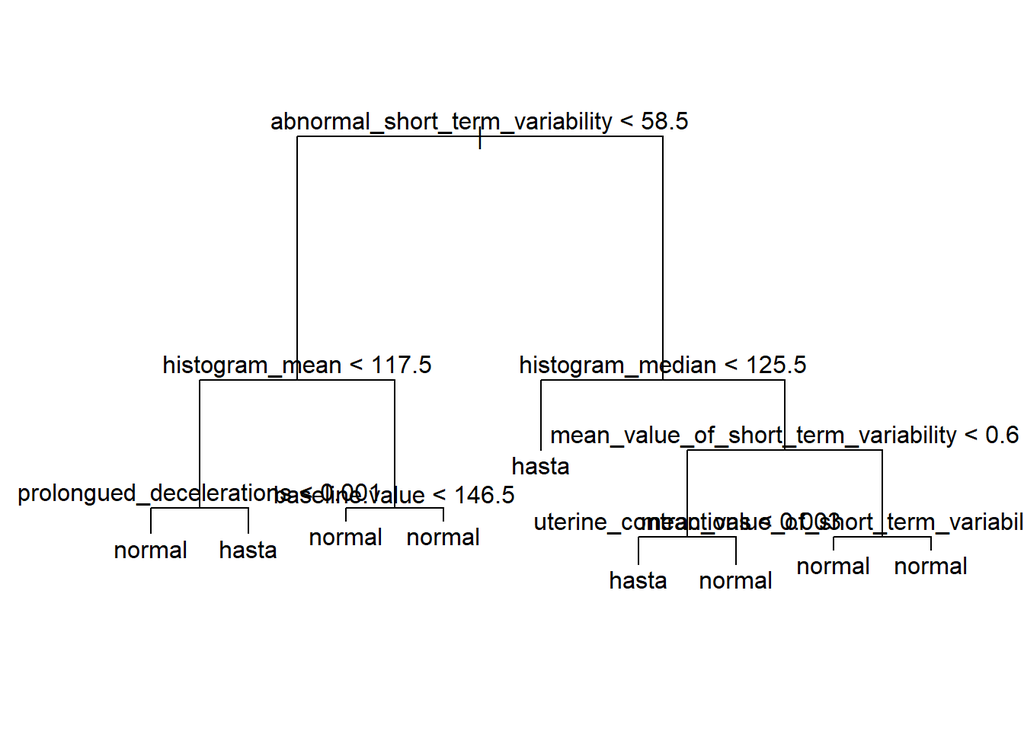

```r
plot(tree.fetal);text(tree.fetal,pretty=0)
```

```r
tree.pred=predict(tree.fetal,fetal.test,type="class")
```

```r
cm <- caret::confusionMatrix(table(tree.pred,health.test))
cm
```

```
## Confusion Matrix and Statistics
##
##          health.test
## tree.pred hasta normal
##    hasta     34      1
##    normal     2     38
##
##                Accuracy : 0.96
##                  95% CI : (0.8875, 0.9917)
##     No Information Rate : 0.52
##     P-Value [Acc > NIR] : <2e-16
##
##                   Kappa : 0.9198
##
##  Mcnemar's Test P-Value : 1
##
##             Sensitivity : 0.9444
##             Specificity : 0.9744
##          Pos Pred Value : 0.9714
##          Neg Pred Value : 0.9500
##              Prevalence : 0.4800
##          Detection Rate : 0.4533
##    Detection Prevalence : 0.4667
##       Balanced Accuracy : 0.9594
##
##        'Positive' Class : hasta
##
```

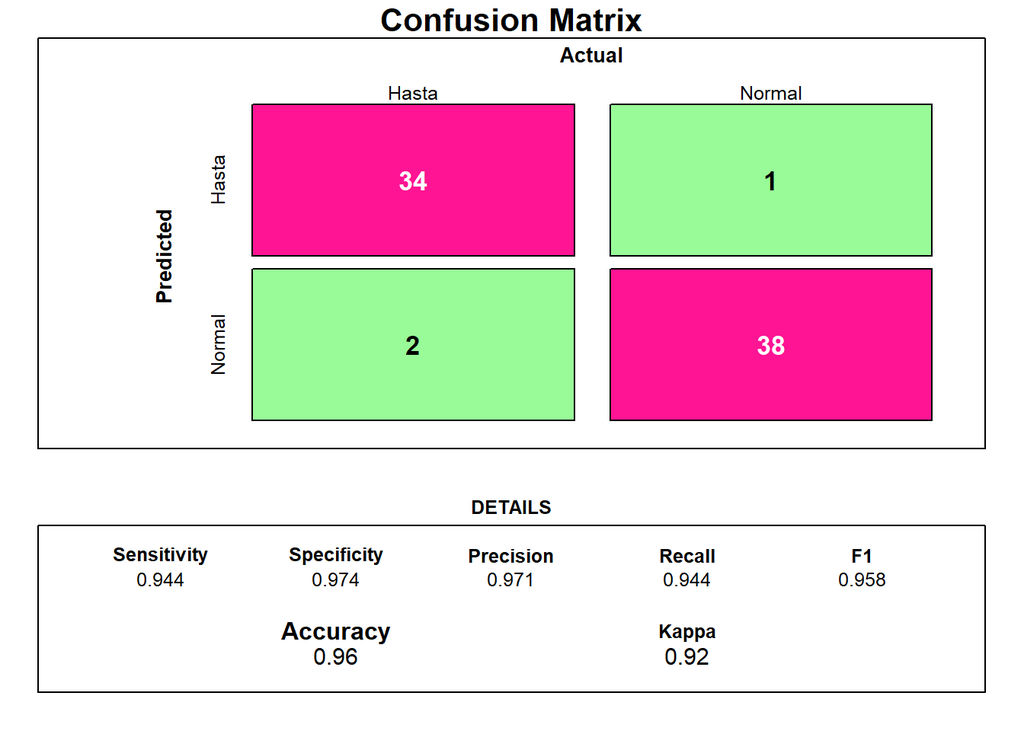

**Modelin test seti üzerindeki doğruluk oranı 0.96 dır.**

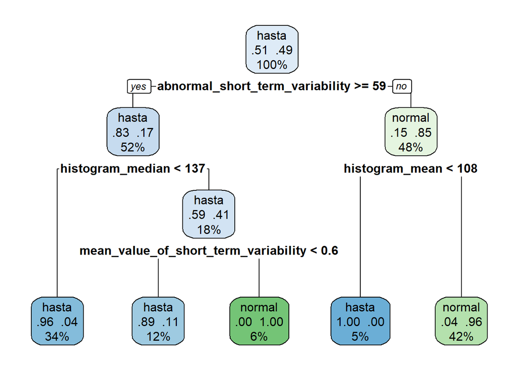

Aynı modeli rpart paketi ile kurduğumda ortaya çıkan ağaç bu şekildedir.

## 2)BUDANMIŞ KARAR AĞACI

Model tahminlerinin varyansını düşürmek ve daha az komplex bir ağaçla çalışmak amacıyla pruning(budama) yapılır.

```r
set.seed(400)
cv.fetal=cv.tree(tree.fetal,FUN=prune.misclass)
cv.fetal
```

```
## $size
## [1] 9 6 5 3 2 1
##
## $dev
## [1]  19  19  19  28  40 135
##
## $k
## [1] -Inf  0.0  2.0  7.5 11.0 75.0
##
## $method
## [1] "misclass"
##
## attr(,"class")
## [1] "prune"         "tree.sequence"
```

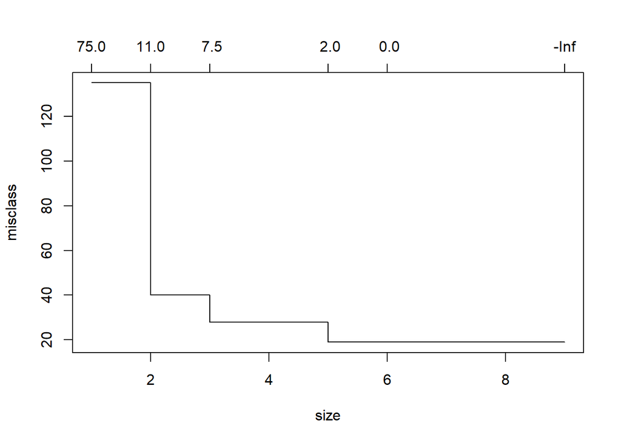

```r
plot(cv.fetal)
```

**Misclassification’ın en düşük değeri size 5 de elde edilmiştir.**

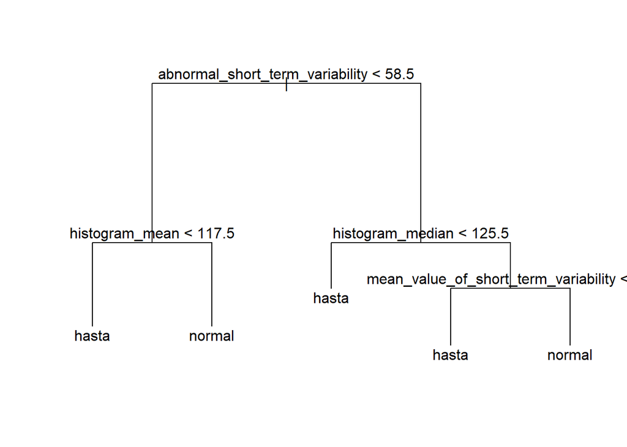

```r
prune.fetal=prune.misclass(tree.fetal,best=5)
plot(prune.fetal);text(prune.fetal,pretty=0)
```

```r
prune.fetal.pred=predict(prune.fetal,fetal.test,type="class")
```

Bu budanmış ağacın tahmin performansını inceleyelim.

```r
cm <- caret::confusionMatrix(table(prune.fetal.pred,health.test))
```

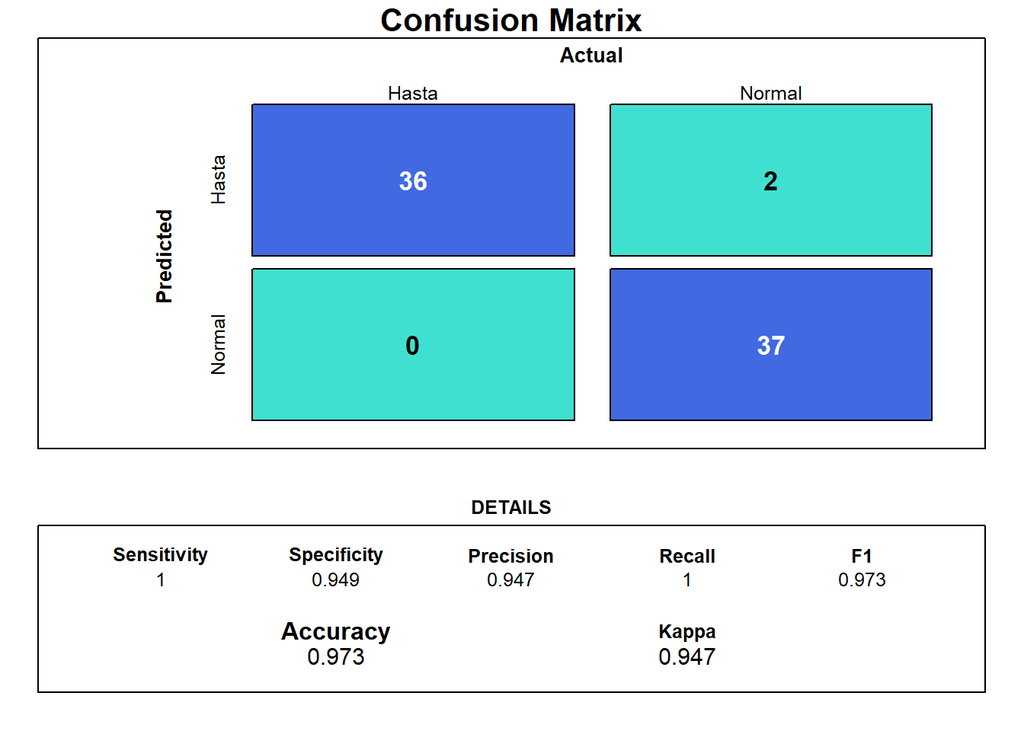

Tahmin performansı artmıştır ve yorumlanması daha kolay bir ağacımız olmuştur.

## 3)BAGGING

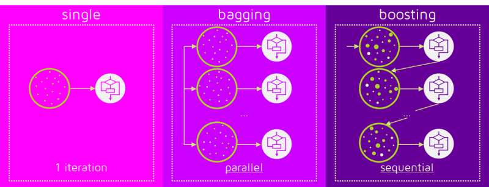

```r
set.seed(500)
train=yeniveri[train,]
Bagging1=randomForest(fetal_health~., data=train, mtry=22, importance=TRUE)
Bagging1
```

```
##
## Call:
##  randomForest(formula = fetal_health ~ ., data = train, mtry = 22,      importance = TRUE)
##                Type of random forest: classification
##                      Number of trees: 500
## No. of variables tried at each split: 21
##
##         OOB estimate of  error rate: 6.67%
## Confusion matrix:
##        hasta normal class.error
## hasta    107      7  0.06140351
## normal     8    103  0.07207207
```

Test seti üzerindeki tahmin performansını inceleyelim.

```r
pred=predict(Bagging1,fetal.test,type="class")
cm <- caret::confusionMatrix(table(fetal.test$fetal_health, pred))
```

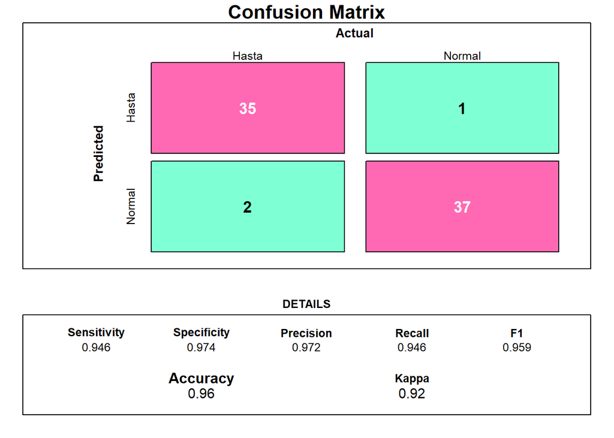

Bagging modelinin doğru tahmin oranı yüzde 96 dir.

Şimdi outof bag error grafiğini çizdirelim.

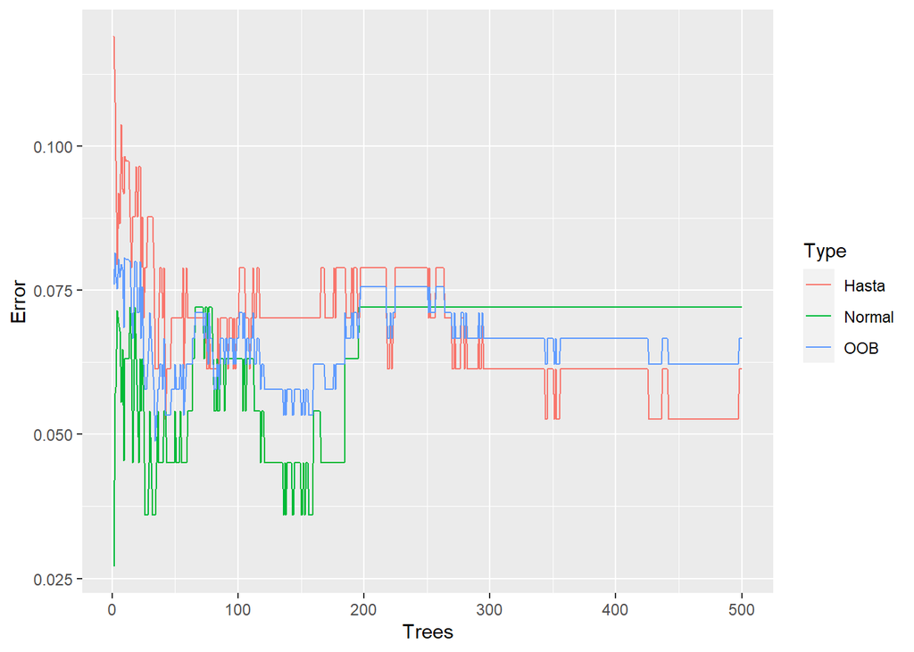

500 ağaç ile kurulan modelin error değeri:

```r
oob.err.data[500,]
```

```
##     Trees Type      Error
## 500   500  OOB 0.06666667
```

İlk 50 ağaç için error değerlerini incelemek istiyorum.

```r
head(oob.err.data,50)
```

```
##    Trees Type      Error
## 1      1  OOB 0.07594937
## 2      2  OOB 0.08148148
## 3      3  OOB 0.07738095
## 4      4  OOB 0.07526882
## 5      5  OOB 0.08040201
## 6      6  OOB 0.07729469
## 7      7  OOB 0.07943925
## 8      8  OOB 0.07870370
## 9      9  OOB 0.06849315
## 10    10  OOB 0.08071749
## 11    11  OOB 0.08035714
## 12    12  OOB 0.08035714
## 13    13  OOB 0.08035714
## 14    14  OOB 0.08000000
```

[output cut: 36 more lines]

**26 ağaç yeterli gözükmektedir.ntree=26 alarak deneyelim.**

## 4)26 Bootstrap sample

```r
set.seed(500)
Bagging2=randomForest(fetal_health~., data=train, mtry=22, ntree=26, importance=TRUE)
Bagging2
```

```
##
## Call:
##  randomForest(formula = fetal_health ~ ., data = train, mtry = 22,      ntree = 26, importance = TRUE)
##                Type of random forest: classification
##                      Number of trees: 26
## No. of variables tried at each split: 21
##
##         OOB estimate of  error rate: 5.78%
## Confusion matrix:
##        hasta normal class.error
## hasta    105      9  0.07894737
## normal     4    107  0.03603604
```

```r
pred=predict(Bagging2,fetal.test,type="class")
cm <- caret::confusionMatrix(table(fetal.test$fetal_health, pred))
```

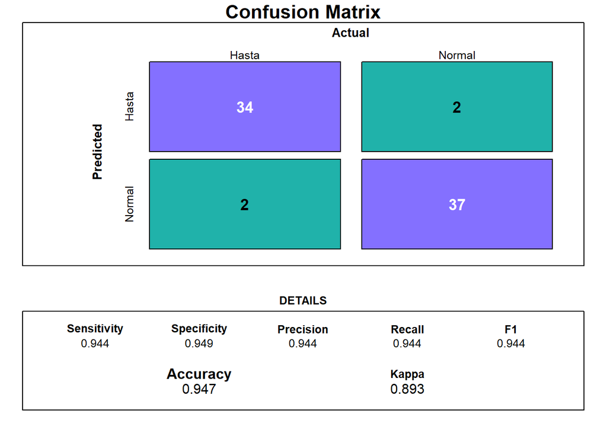

Doğru tahmin oranı 0.947 olmuştur.500 ağaçla kurulan modelde tahmin performansı 0.96 bulunmuştu.Tahmin performansı düşmüştür.

## 5)RANDOM FOREST

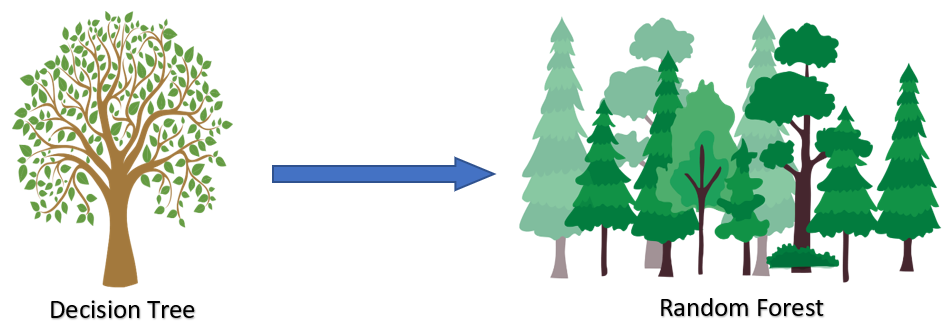

```r
set.seed(500)
Randomforest1=randomForest(fetal_health~., data=train, mtry=4, importance=TRUE)
Randomforest1
```

```
##
## Call:
##  randomForest(formula = fetal_health ~ ., data = train, mtry = 4,      importance = TRUE)
##                Type of random forest: classification
##                      Number of trees: 500
## No. of variables tried at each split: 4
##
##         OOB estimate of  error rate: 4.89%
## Confusion matrix:
##        hasta normal class.error
## hasta    109      5  0.04385965
## normal     6    105  0.05405405
```

```r
pred=predict(Randomforest1,fetal.test,type="class")
cm <- caret::confusionMatrix(table(fetal.test$fetal_health, pred))
```

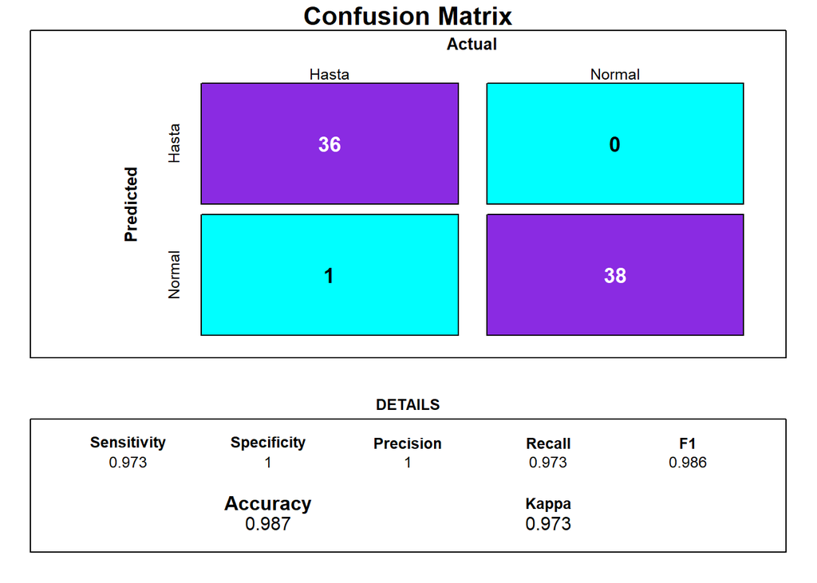

**Doğru tahmin oranı 0.987’dir.**

## 6)BOOSTING

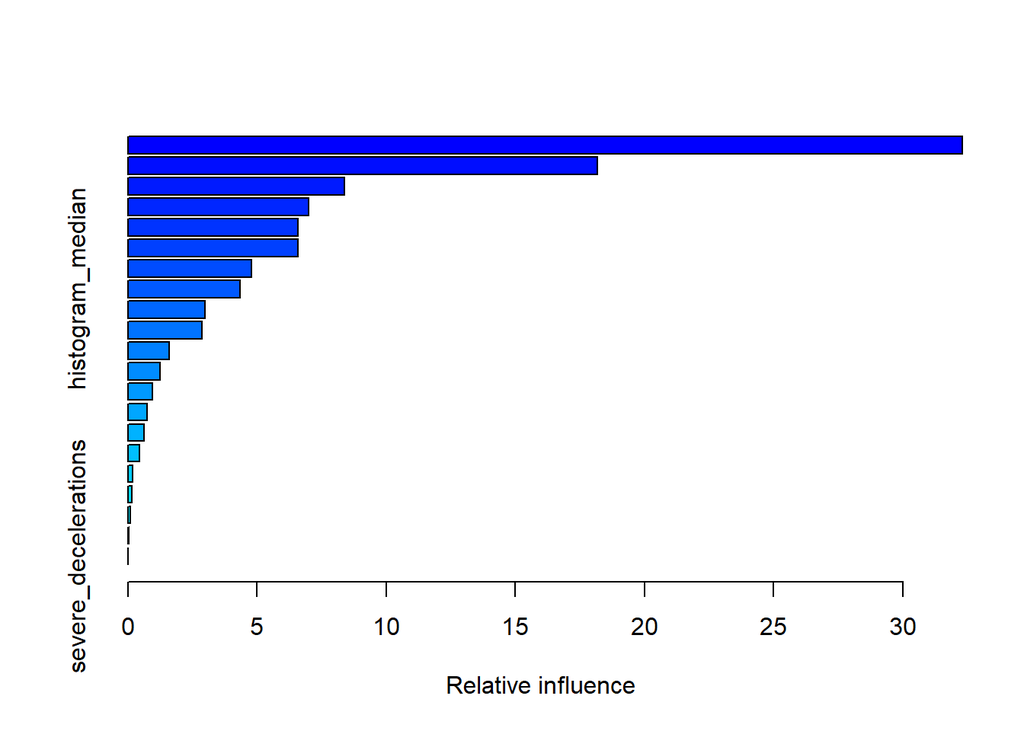

```
##                                                                                                           var
## abnormal_short_term_variability                                               abnormal_short_term_variability
## histogram_mean                                                                                 histogram_mean
## mean_value_of_short_term_variability                                     mean_value_of_short_term_variability
## accelerations                                                                                   accelerations
## uterine_contractions                                                                     uterine_contractions
## percentage_of_time_with_abnormal_long_term_variability percentage_of_time_with_abnormal_long_term_variability
## histogram_variance                                                                         histogram_variance
## histogram_median                                                                             histogram_median
## mean_value_of_long_term_variability                                       mean_value_of_long_term_variability
## prolongued_decelerations                                                             prolongued_decelerations
## histogram_min                                                                                   histogram_min
## histogram_mode                                                                                 histogram_mode
## histogram_width                                                                               histogram_width
## baseline.value                                                                                 baseline.value
## histogram_max                                                                                   histogram_max
## light_decelerations                                                                       light_decelerations
## histogram_tendency                                                                         histogram_tendency
## fetal_movement                                                                                 fetal_movement
## histogram_number_of_peaks                                                           histogram_number_of_peaks
## histogram_number_of_zeroes                                                         histogram_number_of_zeroes
## severe_decelerations                                                                     severe_decelerations
##                                                            rel.inf
## abnormal_short_term_variability                        32.30050932
## histogram_mean                                         18.18539255
## mean_value_of_short_term_variability                    8.37173786
## accelerations                                           6.98729171
## uterine_contractions                                    6.58137299
## percentage_of_time_with_abnormal_long_term_variability  6.57412875
## histogram_variance                                      4.78565046
## histogram_median                                        4.32550197
## mean_value_of_long_term_variability                     2.97901951
## prolongued_decelerations                                2.86619720
## histogram_min                                           1.58352570
## histogram_mode                                          1.23993412
## histogram_width                                         0.94623820
## baseline.value                                          0.73064601
## histogram_max                                           0.61875734
## light_decelerations                                     0.44036637
## histogram_tendency                                      0.19244030
## fetal_movement                                          0.16347716
## histogram_number_of_peaks                               0.09832610
## histogram_number_of_zeroes                              0.02948637
## severe_decelerations                                    0.00000000
```

```r
library(gbm)
set.seed(500)
boosting1=gbm((unclass(fetal_health)-1) ~ ., data=train,
                    distribution="bernoulli",
                    n.trees=5000,
                    interaction.depth=4,
                    verbose = F)
summary(boosting1)
```

“abnormal_short_term_variability” en önemli değişkendir.Ardından “histogram_mean” değişkeni gelmektedir.

```r
pred = predict.gbm(object = boosting1,
                   newdata = fetal.test,
                   n.trees = 200,
                   type = "response")
```

```r
pred=predict(boosting1,fetal.test,type="response")
pred<-ifelse(pred>0.5,"normal","hasta")
table(pred,fetal.test$fetal_health)
```

```
##
## pred     hasta normal
##   hasta     36      4
##   normal     0     35
```

```r
cm <- caret::confusionMatrix(table(pred,fetal.test$fetal_health))
```

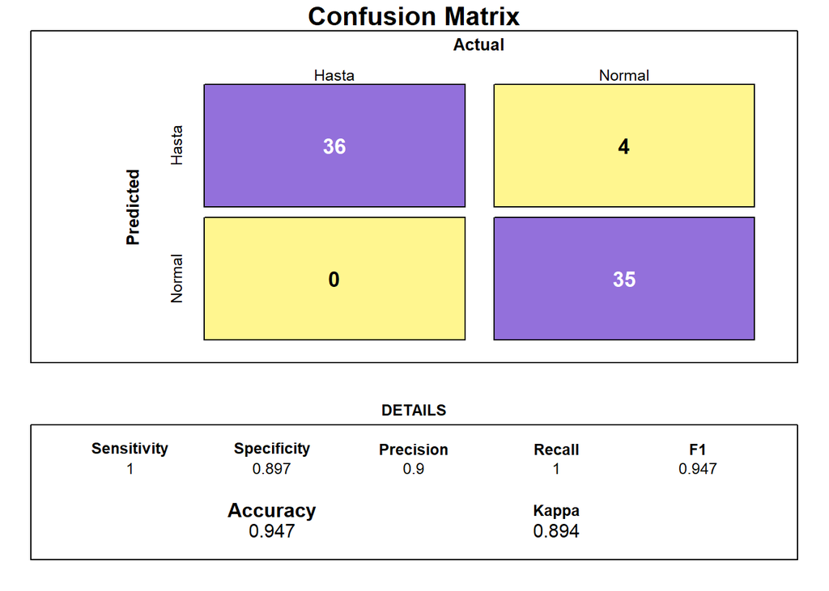

**Doğru tahmin oranı yaklaşık %95 tir.

## 7)Lojistik Regresyon

```r
mod <- glm(fetal_health ~ ., data=train, family=binomial)
```

```r
fetal.test=fetal.test%>% mutate(fetal_health= case_when(fetal_health=="normal"~1,
fetal_health=="hasta"~0))

fetal.test$fetal_health=as.factor(fetal.test$fetal_health)

train=train%>% mutate(fetal_health= case_when(fetal_health=="normal"~1,
fetal_health=="hasta"~0))

train$fetal_health=as.factor(train$fetal_health)
```

Test verisi için tahminlerimizi elde edelim.

```r
predicted <- predict(mod, fetal.test, type="response")  # predicted scores
pred<-ifelse(predicted>0.5,"1","0")
table(pred,fetal.test$fetal_health)
```

```
##
## pred  0  1
##    0 29  1
##    1  7 38
```

```r
misClassError(fetal.test$fetal_health, predicted , threshold = 0.5)
```

```
## [1] 0.1067
```

```r
(29+38)/(75)
```

```
## [1] 0.8933333
```

```r
cm <- caret::confusionMatrix(table(pred,fetal.test$fetal_health))
```

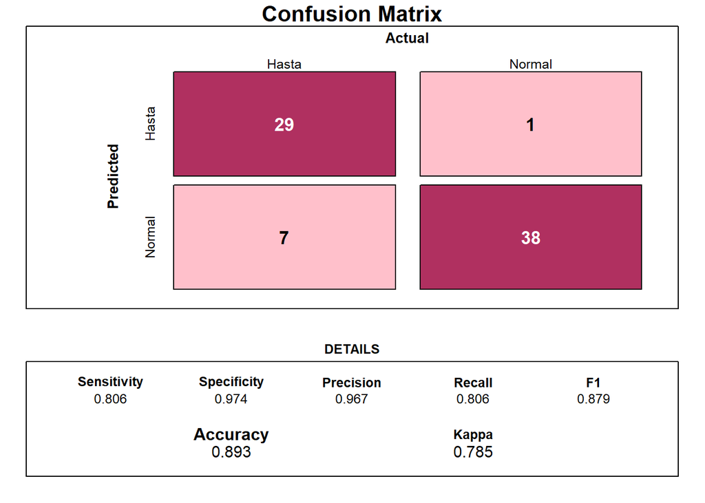

**Doğru tahmin oranı 0.893 bulunmuştur**

##Optimum Cutoff

```r
library(InformationValue)
predictions<-predict(mod,type="response")
optCutOff <- optimalCutoff(train$fetal_health, predictions)[1]
optCutOff
```

```
## [1] 0.01
```

Train set için elde edilen cutoff değeri 0.01 bulunmuştur.

**ROC**

ROC curve altında kalan alan ne kadar büyük ise model o kadar iyidir.

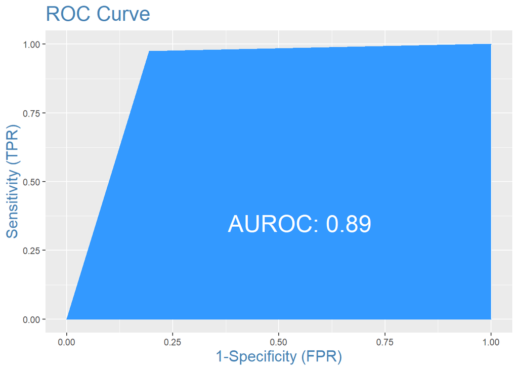

```r
plotROC(fetal.test$fetal_health, predicted)
```

**Concordance**

Eğer gerçekte 1 olarak etiketli olanlara karşılık tahmin edilen olasılık değerlerinin hepsi sıfır olarak etiketli olanlar için tahmin edilenlerden daha yüksek ise concordance 1 dir ve model iyi bir modeldir. Genel olarak concordance 1 olarak etiketli olan gözlemlere karşılık tahmin edilen olasılık değerlerinin sıfır olarak kodlu olanlara karşılık tahmin edilenlerin hepsinden yüksek olarak tahmin edilenlerinin oranını verir. Bu oran nekadar yüksek ise model o kadar iyi ayrıştırma yapıyor demektir.

```r
Concordance(fetal.test$fetal_health, predicted)$Concordance
```

```
## [1] 0.8390313
```

Modelde multicollinearity söz konusu ise bu modelin tahmin performansını etkiler. Bunu da vif komutu ile inceleyebiliriz.

```r
mod <- glm(fetal_health ~ .-histogram_width , data=train, family=binomial)
```

```r
library(car)
car::vif(mod)
```

```
##                                                               GVIF Df
## baseline.value                                         1021.112312  1
## accelerations                                            21.105750  1
## fetal_movement                                            2.770060  1
## uterine_contractions                                     93.292240  1
## light_decelerations                                     101.056020  1
## severe_decelerations                                      1.516062  1
## prolongued_decelerations                                593.635277  1
## abnormal_short_term_variability                          86.532115  1
## mean_value_of_short_term_variability                    235.147912  1
## percentage_of_time_with_abnormal_long_term_variability  111.127600  1
## mean_value_of_long_term_variability                      71.533660  1
## histogram_min                                           184.809286  1
## histogram_max                                           218.039159  1
## histogram_number_of_peaks                               105.576727  1
## histogram_number_of_zeroes                              210.847194  1
## histogram_mode                                         1595.828697  1
## histogram_mean                                         6728.620788  1
## histogram_median                                       7979.364301  1
## histogram_variance                                      815.666951  1
## histogram_tendency                                      462.446907  2
##                                                        GVIF^(1/(2*Df))
## baseline.value                                               31.954848
## accelerations                                                 4.594099
## fetal_movement                                                1.664350
## uterine_contractions                                          9.658791
## light_decelerations                                          10.052662
## severe_decelerations                                          1.231285
## prolongued_decelerations                                     24.364632
## abnormal_short_term_variability                               9.302264
## mean_value_of_short_term_variability                         15.334533
## percentage_of_time_with_abnormal_long_term_variability       10.541708
## mean_value_of_long_term_variability                           8.457757
## histogram_min                                                13.594458
## histogram_max                                                14.766149
## histogram_number_of_peaks                                    10.275054
## histogram_number_of_zeroes                                   14.520578
## histogram_mode                                               39.947825
## histogram_mean                                               82.028171
## histogram_median                                             89.327288
## histogram_variance                                           28.559884
## histogram_tendency                                            4.637303
```

VIF değerlerine bakıldığında birçok değişken için çoklu bağlantı problemi olduğu görülüyor.Bu durum lojistik regresyonda önemlidir ve düzeltilmesi gerekir.

# 1.Soru sonuçları

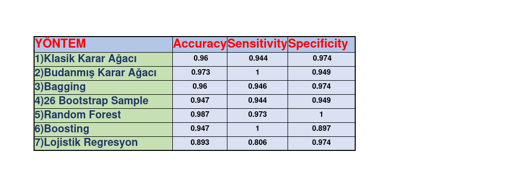

Doğru tahmin oranı en iyi olan yöntem 0.987 ile Random Forest yöntemidir.Random Forest yöntemi aynı zamanda en iyi specificity değerine sahiptir.Sağlıklı olan bebekleri hatasız tahmin etmiştir.Doğru tahmin oranı Random Forest tan sonra en iyi olan yöntem Budanmış Karar Ağacı yöntemidir.

Sensitivity değerine bakıldığında Budanmış Karar Ağacı ve Boosting yöntemi test seti üzerinde hatasız sonuç vermiştir.Yani Hasta olan bebekleri hatasız tahmin eden yöntemlerdir.

Lojistik regresyon doğru tahmin oranı en düşük olan yöntemdir.

# 2.SORU

## Verinin Tanıtılması

11 değişken ve 32686 gözlemden oluşan bir veridir.

**Değişkenlerin tanıtılması**

**1)** **UNIXTime:** *Numara*

**2)** **Data:** *Tarih*

**3)** **Time:** *Saat*

**4)** **Radiation:** *Güneş radyasyonu(metre başına watt ^ 2)*

**5)** **Temperature:** *Sıcaklık (Fahrenheit derece)*

**6)** **Pressure:** *Barometrik basınç(Hg)*

**7)** **Humidity:** *Nem(yüzde)*

**8)** **WindDirection.Degrees.:** *Rüzgar yönü(derece)*

**9)** **Speed:** *Rüzgar hızı(saatte mil)*

**10)** **TimeSunRise:** *Gün doğumu (Hawaii saati)*

**11)** **TimeSunSet:** *gün batımı(Hawaii saati)*

**Sıcaklık,Basınç,Nem,Rüzgar Yönü,Rüzgar Hızı değişkenleri kullanılarak RADYASYON tahmin edilecektir.**

Solar

| UNIXTime | Data | Time | Radiation | Temperature | Pressure | Humidity | WindDirection.Degrees. | Speed | TimeSunRise | TimeSunSet |
| --- | --- | --- | --- | --- | --- | --- | --- | --- | --- | --- |
| 1475229326 | 9/29/2016 12:00:00 AM | 23:55:26 | 1.21 | 48 | 30.46 | 59 | 177.39 | 5.62 | 06:13:00 | 18:13:00 |
| 1475229023 | 9/29/2016 12:00:00 AM | 23:50:23 | 1.21 | 48 | 30.46 | 58 | 176.78 | 3.37 | 06:13:00 | 18:13:00 |
| 1475228726 | 9/29/2016 12:00:00 AM | 23:45:26 | 1.23 | 48 | 30.46 | 57 | 158.75 | 3.37 | 06:13:00 | 18:13:00 |
| 1475228421 | 9/29/2016 12:00:00 AM | 23:40:21 | 1.21 | 48 | 30.46 | 60 | 137.71 | 3.37 | 06:13:00 | 18:13:00 |
| 1475228124 | 9/29/2016 12:00:00 AM | 23:35:24 | 1.17 | 48 | 30.46 | 62 | 104.95 | 5.62 | 06:13:00 | 18:13:00 |
| 1475227824 | 9/29/2016 12:00:00 AM | 23:30:24 | 1.21 | 48 | 30.46 | 64 | 120.20 | 5.62 | 06:13:00 | 18:13:00 |

```r
Solar=Solar%>%dplyr::select("Radiation","Temperature","Pressure","Humidity","WindDirection.Degrees.","Speed")
Solar$Temperature=as.numeric(Solar$Temperature)
Solar$Humidity=as.numeric(Solar$Humidity)

str(Solar)
```

```
## 'data.frame':    32686 obs. of  6 variables:
##  $ Radiation             : num  1.21 1.21 1.23 1.21 1.17 1.21 1.2 1.24 1.23 1.21 ...
##  $ Temperature           : num  48 48 48 48 48 48 49 49 49 49 ...
##  $ Pressure              : num  30.5 30.5 30.5 30.5 30.5 ...
##  $ Humidity              : num  59 58 57 60 62 64 72 71 80 85 ...
##  $ WindDirection.Degrees.: num  177 177 159 138 105 ...
##  $ Speed                 : num  5.62 3.37 3.37 3.37 5.62 5.62 6.75 5.62 4.5 4.5 ...
```

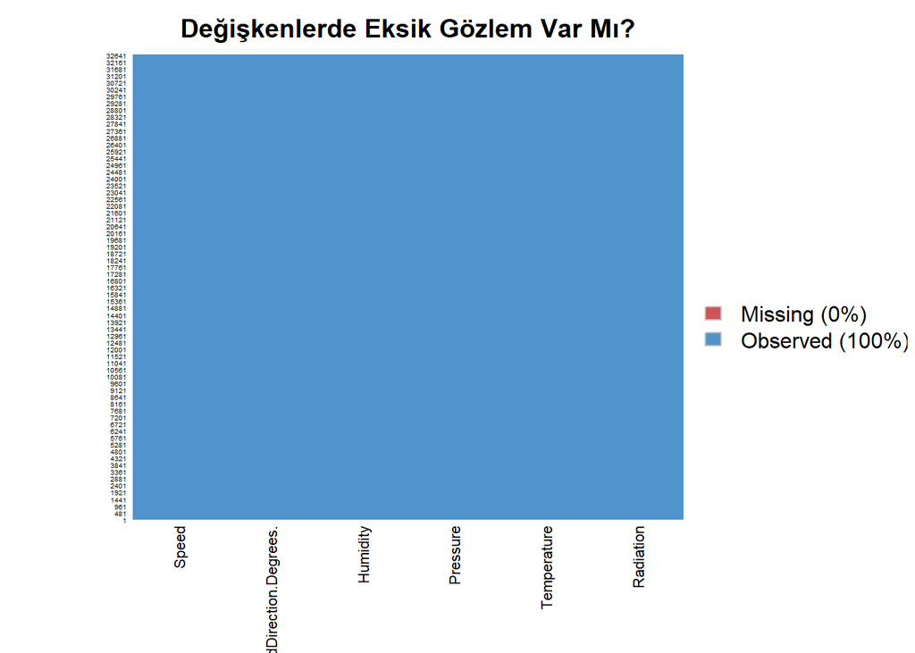

Veride eksik gözlem yoktur.

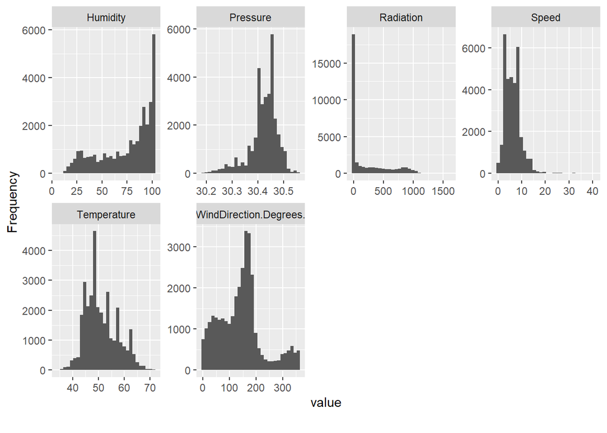

```r
dim(Solar)
```

```
## [1] 32686     6
```

Çok fazla gözlem var.Bu gözlemlerin ilk 1500 tanesini alıp veriyi yeniden oluşturuyorum.

```r
Solar=Solar[1:1500,]
1500*75/100 #train set olarak alınacak.
```

```
## [1] 1125
```

## 1)Klasik Yöntem

```r
set.seed(300)
train = sample(1:nrow(Solar),1125) #%75 train
tree.Solar=tree(Radiation~.,Solar,subset=train) #%25 test
summary(tree.Solar)
```

```
##
## Regression tree:
## tree(formula = Radiation ~ ., data = Solar, subset = train)
## Variables actually used in tree construction:
## [1] "Temperature" "Humidity"
## Number of terminal nodes:  6
## Residual mean deviance:  19690 = 22030000 / 1119
## Distribution of residuals:
##     Min.  1st Qu.   Median     Mean  3rd Qu.     Max.
## -569.200  -11.320  -11.290    0.000    5.425  653.500
```

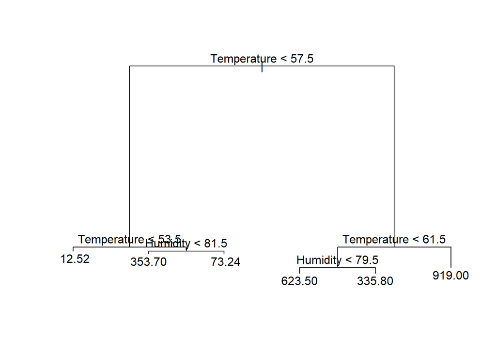

```r
plot(tree.Solar)
text(tree.Solar,pretty=0)
```

Ağacı budamaya gerek olup olmadığını inceleyim.

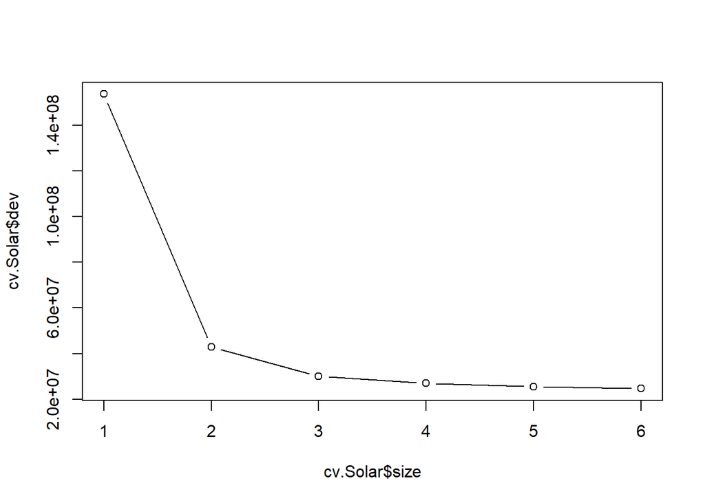

```r
cv.Solar=cv.tree(tree.Solar,method="deviance")
plot(cv.Solar$size,cv.Solar$dev,type='b')
```

Ağacı budamaya gerek yoktur.

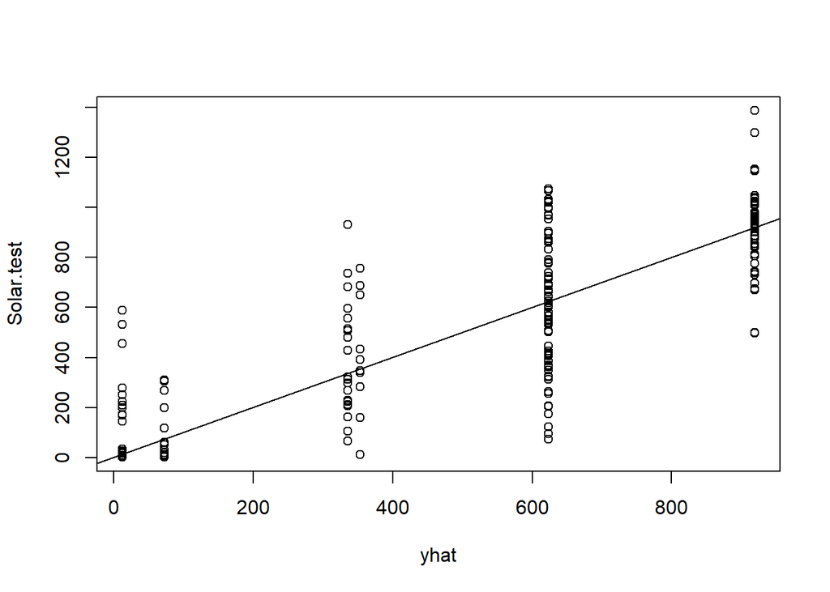

```r
yhat=predict(tree.Solar,newdata=Solar[-train,])
Solar.test=Solar[-train,"Radiation"]
plot(yhat,Solar.test)
abline(0,1)
```

```r
mean((yhat-Solar.test)^2)
```

```
## [1] 24393.74
```

## 2)Bagging

Eğer mtray=p alırsak bagging yapmış oluruz. Default bootstrap sample sayısı 500 dür.Default taki gibi çalıştıralım.

```r
set.seed(100)
bag.Solar=randomForest(Radiation~.,data=Solar,subset=train,mtry=6,importance=TRUE)
bag.Solar
```

```
##
## Call:
##  randomForest(formula = Radiation ~ ., data = Solar, mtry = 6,      importance = TRUE, subset = train)
##                Type of random forest: regression
##                      Number of trees: 500
## No. of variables tried at each split: 5
##
##           Mean of squared residuals: 11364.56
##                     % Var explained: 91.67
```

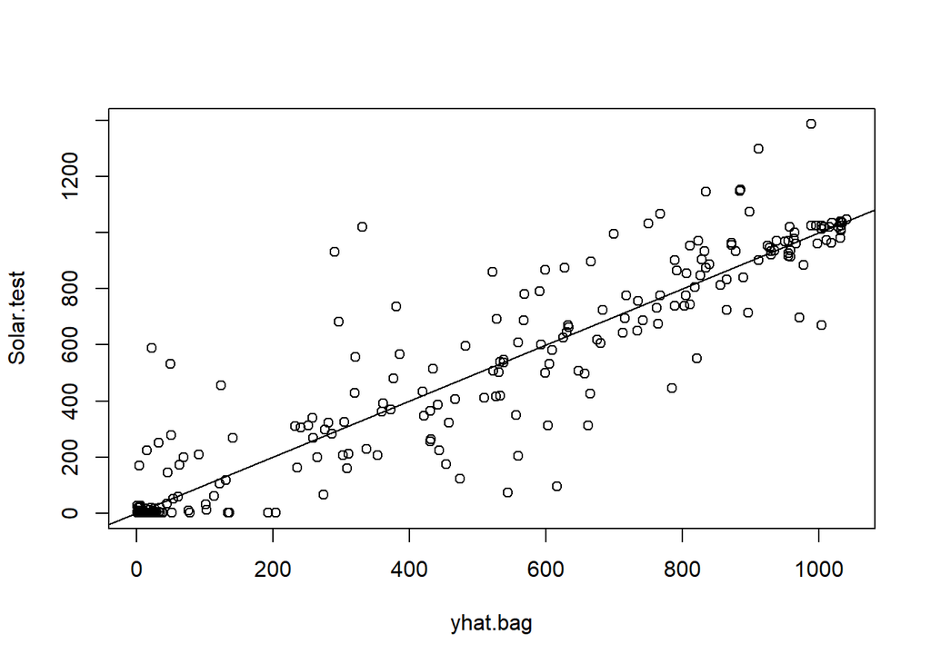

```r
yhat.bag = predict(bag.Solar,newdata=Solar[-train,])
plot(yhat.bag,Solar.test)
abline(0,1)
```

MSE değeri 11364 bulunmuştur ve toplam varyansın %91.67 sini açıklamaktadır. Bu MSE ve Explained Variance değerleri out of bag error değerleri kullanılarak elde edilmiştir. Çizilen saçılım grafiğinden tahmin performansının tek bir ağaç ile elde edilen modele göre çok daha iyi olduğu anlaşılmaktadır.

```r
mean((yhat.bag-Solar.test)^2)
```

```
## [1] 15350.24
```

Şimdi outof bag error grafiğini çizdirelim.

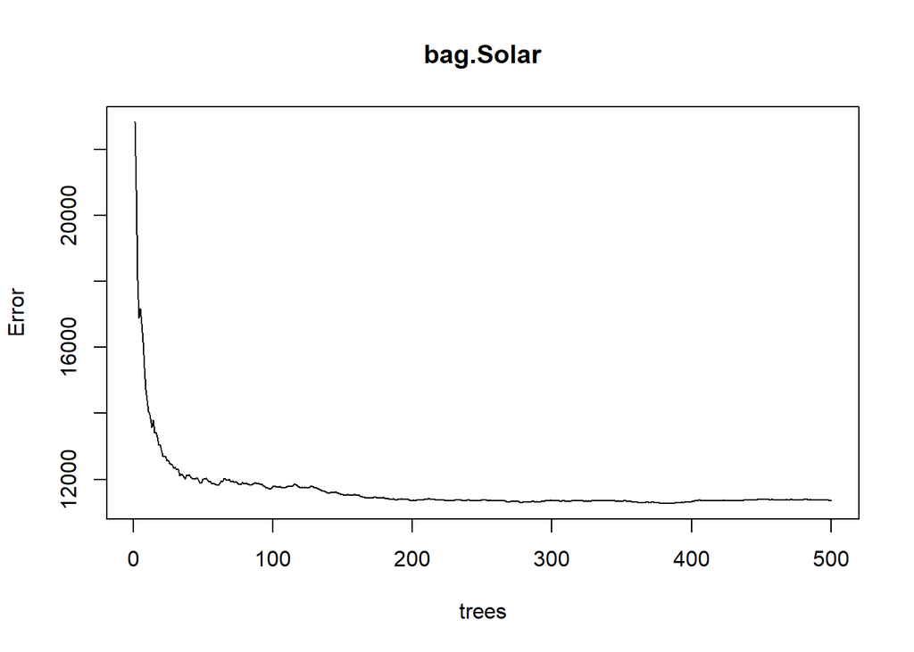

```r
plot(bag.Solar)
```

Görüldüğü gibi 200 civarından sonra MSE değerleri çok büyük bir değişkenlik göstermemektedir. İlk 200 değere bakacak olursak bunu görebiliriz.

```r
head(bag.Solar$mse,200)
```

```
##   [1] 22834.20 20780.79 18052.14 16888.69 17176.23 16724.94 16179.47 15388.81
##   [9] 14727.93 14406.29 14074.95 13964.75 13581.07 13797.50 13419.44 13434.65
##  [17] 13286.30 13049.83 13068.46 12888.04 12716.02 12686.03 12707.81 12565.72
##  [25] 12585.05 12489.24 12475.21 12447.21 12337.74 12360.50 12307.18 12302.06
##  [33] 12111.76 12151.49 12141.23 12067.84 12001.87 12128.68 12124.25 12140.48
##  [41] 12080.01 12036.26 12009.48 12015.38 12029.29 12032.06 11975.15 11888.02
##  [49] 11889.74 12005.27 12021.48 12024.72 11963.11 11921.04 11919.34 11877.26
##  [57] 11864.10 11862.05 11851.31 11832.56 11823.57 11891.26 11954.14 11925.91
##  [65] 12023.75 12005.17 11961.54 11968.48 12010.80 11921.45 11941.26 11909.93
##  [73] 11925.45 11901.06 11864.06 11842.37 11854.78 11904.86 11869.90 11860.62
##  [81] 11882.82 11849.56 11845.68 11824.74 11847.40 11860.52 11882.35 11889.36
##  [89] 11863.81 11858.43 11847.20 11850.89 11804.92 11775.35 11751.92 11739.88
##  [97] 11719.17 11713.01 11743.75 11777.71 11777.45 11786.22 11774.67 11761.87
## [105] 11778.37 11767.67 11753.49 11738.37 11771.60 11778.12 11790.97 11787.10
## [113] 11781.52 11801.44 11842.04 11853.71 11821.76 11793.76 11769.31 11752.42
## [121] 11768.17 11742.34 11755.97 11738.83 11750.98 11747.37 11779.57 11791.62
## [129] 11774.57 11750.68 11742.25 11720.58 11708.05 11685.26 11656.40 11647.54
## [137] 11639.00 11621.14 11608.78 11585.92 11591.73 11607.46 11604.29 11596.64
## [145] 11610.93 11605.13 11587.58 11569.20 11537.26 11531.30 11526.28 11507.92
## [153] 11531.29 11532.75 11519.14 11522.52 11518.02 11533.82 11535.01 11512.79
## [161] 11515.97 11509.57 11478.77 11476.95 11447.07 11448.39 11427.86 11427.86
## [169] 11425.38 11438.21 11435.21 11446.36 11451.73 11461.07 11439.18 11429.72
## [177] 11427.26 11443.06 11448.73 11440.07 11424.35 11424.72 11408.24 11401.30
## [185] 11402.44 11411.05 11386.79 11381.97 11389.06 11391.30 11402.67 11416.03
## [193] 11400.31 11393.83 11394.65 11391.22 11393.72 11364.07 11359.68 11362.27
```

## 3)47 Bootstrap Sample

Bakıldığında 47 den sonra fazla değişim olmadığı görülmektedir.Şimdi ntree 47 için deneyelim.

```r
bag.Solar=randomForest(Radiation~.,data=Solar,subset=train,mtry=6,ntree=47)
yhat.bag = predict(bag.Solar,newdata=Solar[-train,])
mean((yhat.bag-Solar.test)^2)
```

```
## [1] 16023.68
```

mse değerinde artış olmuştur.Ağacımız daha sadedir fakat tahmin performansı düşmüştür.

## 4)RANDOM FOREST

[figure not shown]

mtry=karekök p alınarak random forest yapılır.

```r
set.seed(1)
rf.Solar=randomForest(Radiation~.,data=Solar,subset=train,mtry=2,importance=TRUE)
yhat.rf = predict(rf.Solar,newdata=Solar[-train,])
mean((yhat.rf-Solar.test)^2)
```

```
## [1] 14476.41
```

Görüldüğü üzere test verisi üzerinde hesaplanan MSE değeri düşmüştür. Şimdi farklı mtray değerleri için outof bag mse değerleri ile test verisi mse değerlerini karşılaştıralım.

```r
oob.err<-double(6)
test.err<-double(6)

#mtry is no of Variables randomly chosen at each split
for(mtry in 1:6)
{
  rf=randomForest(Radiation ~ . , data = Solar , subset = train,mtry=mtry,ntree=500)
  oob.err[mtry] = rf$mse[500] #Error of all Trees fitted

  pred<-predict(rf,Solar[-train,]) #Predictions on Test Set for each Tree
  test.err[mtry]= with(Solar[-train,], mean( (Radiation - pred)^2)) #Mean Squared Test Error

  cat(mtry," ")

}
```

```
## 1  2  3  4  5  6
```

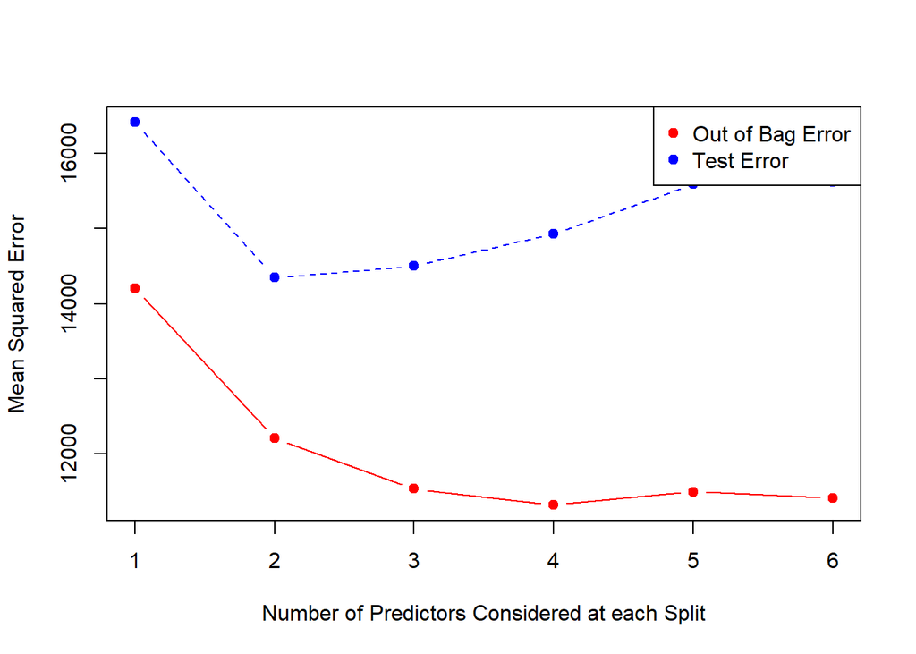

```r
matplot(1:mtry , cbind(oob.err,test.err), pch=19 , col=c("red","blue"),type="b",ylab="Mean Squared Error",xlab="Number of Predictors Considered at each Split")
legend("topright",legend=c("Out of Bag Error","Test Error"),pch=19, col=c("red","blue"))
```

Bu grafikten test seti için mtray=2 alınmasının daha uygun olduğu görünüyor. mtray=2 için hesaplanan test verisi mse değeri

```r
test.err[2]
```

```
## [1] 14348.74
```

Değişkenlerin önemliliklerini inceleyelim.

```r
importance(rf.Solar)
```

```
##                          %IncMSE IncNodePurity
## Temperature            119.41337      84712935
## Pressure                42.69692       6317632
## Humidity                48.59921      22007356
## WindDirection.Degrees.  19.26343      31731442
## Speed                   23.13533       5990280
```

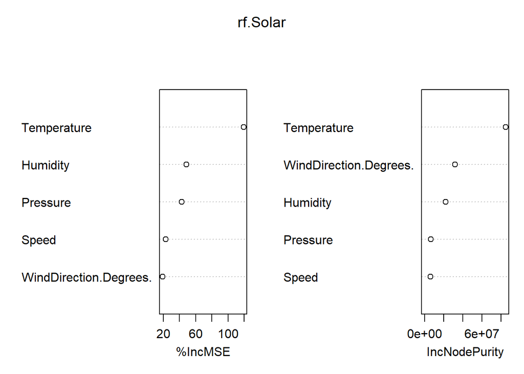

```r
varImpPlot(rf.Solar)
```

Sıcaklığın en önemli değişken olduğu görülmektedir.